# CC para resíduos AR(1)

```r
Sys.setenv(lang = "en_US")
```

```r
knitr::opts_chunk$set(
  out.height = "\\textheight",
  out.width = "\\textwidth",
  out.extra = 'keepaspectratio=true class="chart-image"',
  fig.align = "center"
)
```

## Série para criação dos limites de controle

```r
PARAMETROS <- data.frame(
  phi = 0.2,
  media = 0,
  sd = 1,
  n_h0 = 100,
  n_h1 = 200
)
```

```r
set.seed(1)

gerar_amostra_inicial <- function(){
  amostra_inicial <- ts(simulacao_ar_1(list(n = PARAMETROS$n_h0, phi = PARAMETROS$phi)))
  modelo <- arima(amostra_inicial, order = c(1, 0, 0), include.mean = FALSE)
  residuos <- modelo$residuals

  list(
    serie = amostra_inicial,
    x0 = amostra_inicial[1],
    xn = amostra_inicial[PARAMETROS$n_h0],
    modelo = modelo,
    residuos = residuos,
    phi = coef(modelo)[[1]],
    sd_res = sd(residuos),
    media_res = mean(residuos)
  )
}

amostra_inicial <- gerar_amostra_inicial()
amostra_inicial$modelo
```

```
##
## Call:
## arima(x = amostra_inicial, order = c(1, 0, 0), include.mean = FALSE)
##
## Coefficients:
##          ar1
##       0.2111
## s.e.  0.0975
##
## sigma^2 estimated as 0.81:  log likelihood = -131.38,  aic = 266.76
```

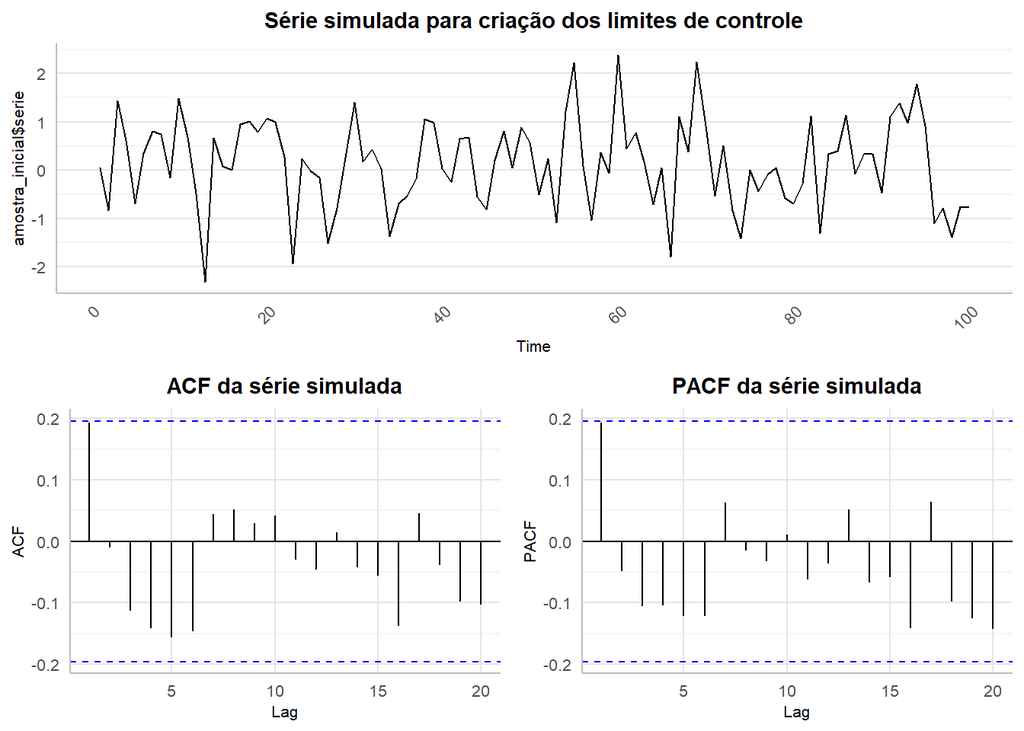

```r
grid.arrange(
  autoplot(amostra_inicial$serie) + ggtitle("Série simulada para criação dos limites de controle") + theme.base + theme.ts,
  ggAcf(amostra_inicial$serie) + ggtitle("ACF da série simulada") + theme.base,
  ggPacf(amostra_inicial$serie) + ggtitle("PACF da série simulada") + theme.base,
  layout_matrix = rbind(c(1, 1), c(2, 3))
)
```

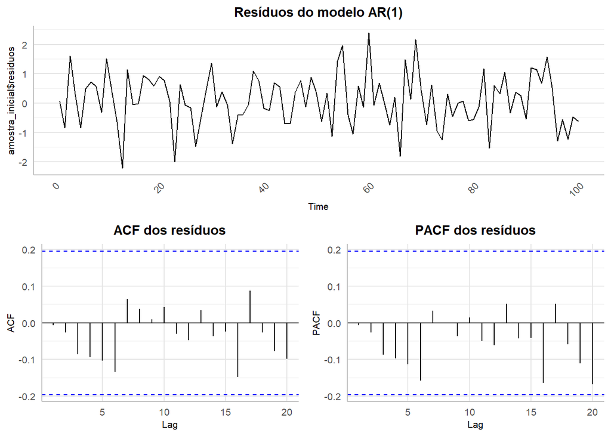

```r
grid.arrange(
  autoplot(amostra_inicial$residuos) + ggtitle("Resíduos do modelo AR(1)") + theme.base + theme.ts,
  ggAcf(amostra_inicial$residuos) + ggtitle("ACF dos resíduos") + theme.base,
  ggPacf(amostra_inicial$residuos) + ggtitle("PACF dos resíduos") + theme.base,
  layout_matrix = rbind(c(1, 1), c(2, 3))
)
```

### Limites de controle

```r
alpha <- 0.05
max_devio <- qnorm(1 - alpha/2) * amostra_inicial$sd_res
limites <- mean(amostra_inicial$residuos) + c(-max_devio, max_devio)

tabela_estatisticas_residuos <- function() {
  tabela <- data.frame(
    "mean" = amostra_inicial$media_res,
    "sd" = amostra_inicial$sd_res,
    "IL" = limites[1],
    "SL" = limites[2]
  )
  colnames(tabela) <- c("Média", "Desvio padrão", "Limite inferior", "Limite superior")
  t(tabela)
}

knitr::kable(
  tabela_estatisticas_residuos(),
  caption = "Intervalo de confiança dos resíduos",
  align = 'c',
  digits = 3
)
```

Intervalo de confiança dos resíduos

| Média | 0.106 |
| --- | --- |
| Desvio padrão | 0.898 |
| Limite inferior | -1.654 |
| Limite superior | 1.867 |

```r
phi_0_para_amostras_seguintes <- seq(0, 0.8, by = 0.1)
n_simulacoes <- length(phi_0_para_amostras_seguintes)

amostras_subsequentes <- lapply(
  phi_0_para_amostras_seguintes,
  function(phi_amostra) ts(simulacao_ar_1(list(n = PARAMETROS$n_h1, phi = phi_amostra, x0 = amostra_inicial$xn)))
)
```

## Simulações

Amostras subsequentes para $\phi_0 \in \{0, 0.1, 0.2, \ldots, 0.8\}$ com $n = 200$.

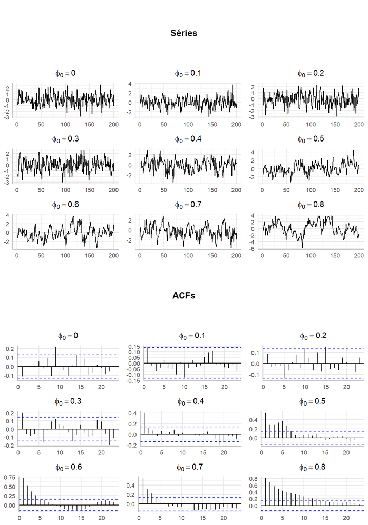

```r
graficos_series <- function(dados) {
  lista <- c()
  for (i in 1:(n_simulacoes)) {
    lista[[i]] <- autoplot(amostras_subsequentes[[i]]) +
      ggtitle(TeX(sprintf("$\\phi_0=%.1f$", phi_0_para_amostras_seguintes[i]))) +
      theme.base +
      theme.no_axis_title
  }
  lista
}

graficos_resid <- function(dados) {
  lista <- c()
  for (i in 1:(n_simulacoes)) {
    lista[[i]] <- ggAcf(amostras_subsequentes[[i]]) +
      ggtitle(TeX(sprintf("$\\phi_0=%.1f$", phi_0_para_amostras_seguintes[i]))) +
      theme.base +
      theme.no_axis_title
  }
  lista
}

grid.arrange(
  grobs = (
    \() {
      lista_graficos <- c()

      # Séries
      lista_graficos[[2]] <- textGrob("Séries", gp = gpar(fontface = "bold", fontsize = 12))
      lista_graficos[[3]] <- textGrob("")
      lista_graficos <- c(lista_graficos, graficos_series(amostras_subsequentes))

      # Resíduos
      lista_graficos[[length(lista_graficos) + 2]] <- textGrob("ACFs", gp = gpar(fontface = "bold", fontsize = 12))
      lista_graficos[[length(lista_graficos) + 1]] <- textGrob("")
      lista_graficos <- c(lista_graficos, graficos_resid(amostras_subsequentes))
      lista_graficos
    }
  )(),
  ncol = 3,
  widths = c(1, 1, 1)
)
```

## Cartas de controle para os resíduos

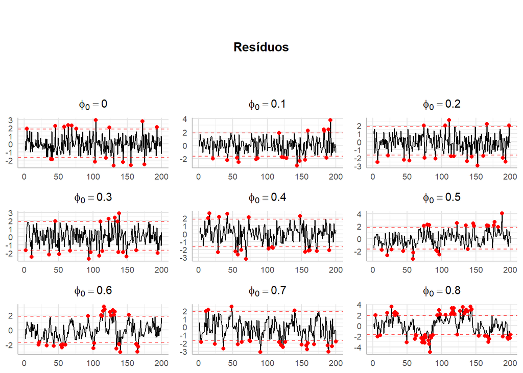

```r
residuos_subsequentes <- lapply(amostras_subsequentes, function(amostra) Arima(amostra, model = amostra_inicial$modelo)$residuals)

cartas_controle <- function(dados) {
  lista <- c()
  for (i in 1:(n_simulacoes)) {
    residuos <- residuos_subsequentes[[i]]
    resid_layer <- autolayer(residuos_subsequentes[[i]])
    fora_de_controle = resid_layer$layer_data() %>% filter(seriesVal < limites[1] | seriesVal > limites[2])

    lista[[i]] <- autoplot(residuos) +
      geom_hline(yintercept = limites, linetype = "dashed", color = "red", alpha = 0.6) +
      geom_point(data = fora_de_controle, aes(x = timeVal, y = seriesVal), color = "red") +
      theme.base +
      theme.no_axis_title +
      theme(legend.position = "none") +
      labs(x = "Resíduos", y = "Observação") +
      ggtitle(TeX(sprintf("$\\phi_0=%.1f$", phi_0_para_amostras_seguintes[i])))
  }
  lista
}

grid.arrange(
  grobs = (
    \() {
      lista_graficos <- c()
      lista_graficos[[2]] <- textGrob("Resíduos", gp = gpar(fontface = "bold", fontsize = 12))
      lista_graficos[[3]] <- textGrob("")
      lista_graficos <- c(lista_graficos, cartas_controle(amostras_subsequentes))
      lista_graficos
    }
  )(),
  ncol = 3,
  widths = c(1, 1, 1)
)
```

### Quantidade de amostras fora de controle para cada $\phi_0$

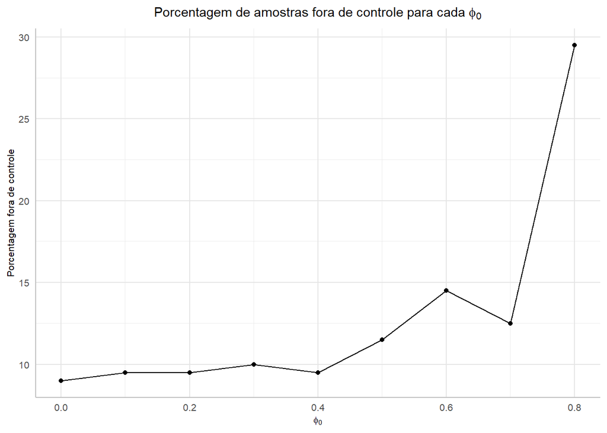

```r
quantidade_fora_de_controle <- sapply(residuos_subsequentes, function(residuos) {
  sum(residuos < limites[1] | residuos > limites[2])
})

tabela_estatisticas_amostras <- function() {
  tabela <- data.frame(
    "phi_0" = phi_0_para_amostras_seguintes,
    "fora" = quantidade_fora_de_controle,
    "prop" = 100 * quantidade_fora_de_controle / PARAMETROS$n_h1
  )
  colnames(tabela) <- c("$\\phi_0$", "Amostras fora de controle", "Proporção (%)")
  tabela
}

ggplot(tabela_estatisticas_amostras(), aes(x = `$\\phi_0$`, y = `Proporção (%)`)) +
  geom_point() +
  geom_line() +
  labs(x = TeX("$\\phi_0$"), y = "Porcentagem fora de controle") +
  ggtitle(TeX("Porcentagem de amostras fora de controle para cada $\\phi_0$")) +
  theme.base
```

```r
kable(
  tabela_estatisticas_amostras(),
  caption = "Quantidade de amostras fora de controle para cada $\\phi_0$",
  align = 'c',
  digits = 3
)
```

Quantidade de amostras fora de controle para cada $\phi_0$

| $\phi_0$ | Amostras fora de controle | Proporção (%) |
| --- | --- | --- |
| 0.0 | 18 | 9.0 |
| 0.1 | 19 | 9.5 |
| 0.2 | 19 | 9.5 |
| 0.3 | 20 | 10.0 |
| 0.4 | 19 | 9.5 |
| 0.5 | 23 | 11.5 |
| 0.6 | 29 | 14.5 |
| 0.7 | 25 | 12.5 |
| 0.8 | 59 | 29.5 |

## EWMA-AR

Minimizando a soma dos quadrados dos resíduos para encontrar o melhor valor de $\lambda$.

Temos que $\lambda \in (0, 1]$, além disso, a previsão para a observação $x_{t+1}$ é dada por $\hat{x}_{t+1}(t)=z_{t} = \lambda x_t + (1 - \lambda) z_{t-1}$. E, segundo Montgomery, Eq. 10.16, temos que os erros de previsão são dados por $e_t = x_t - \hat{x}_t(t-1)$.

Ou, de outra forma
$$\min\big(\underset{\lambda\in(0,1]}{\arg\min}\,\text{Err}(\lambda)\big)$$
onde $\text{Err}(\lambda) = \sum_{t=1}^{n} e_t^2$.

```r
ewma_ar <- function(dados, lambda) {
  n <- length(dados)
  ewma <- numeric(n)
  residuos <- numeric(n)
  ewma[1] <- dados[1]
  residuos[1] <- dados[1]
  for (i in 2:n) {
    ewma[i] <- lambda * dados[i] + (1 - lambda) * ewma[i - 1]
    residuos[i] <- dados[i] - ewma[i - 1]
  }
  data.frame(ewma = ewma, residuos = residuos)
}

lambdas_verificados <- c()
soma_quadrados <- c()
verifica_lambda <- function(lambda) {
  ewma <- ewma_ar(
    amostra_inicial$serie,
    lambda = lambda
  )
  soma <- sum(ewma$residuos^2)
  lambdas_verificados <<- c(lambdas_verificados, lambda)
  soma_quadrados <<- c(soma_quadrados, soma)
  soma
}


lambda_otimo <- optimize(verifica_lambda, c(0.000001, 1))
lambdas_df <- data.frame(lambda = lambdas_verificados, erro = soma_quadrados)
```

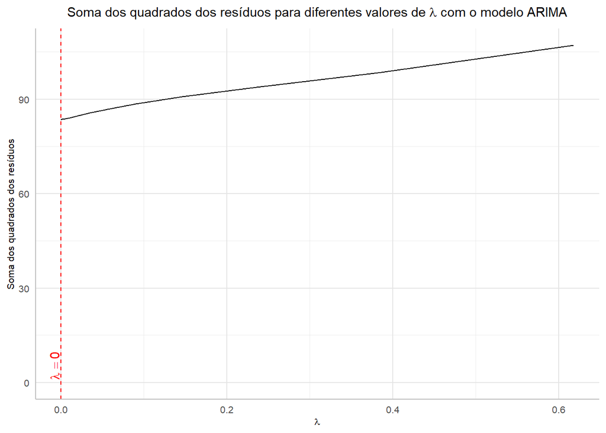

```r
ggplot(data = lambdas_df) +
  geom_line(aes(x = lambda, y = erro)) +
  geom_vline(xintercept = lambda_otimo$minimum, linetype = "dashed", color = "red") +
  annotate("text", x = lambda_otimo$minimum, y = 0,
           label = TeX(sprintf("$\\lambda=%.3f$", lambda_otimo$minimum)), color = "red",
           hjust = -0.1, vjust = -0.2, na.rm = T, angle = 90) +
  labs(x = TeX("$\\lambda$"), y = "Soma dos quadrados dos resíduos") +
  ggtitle(TeX("Soma dos quadrados dos resíduos para diferentes valores de $\\lambda$ com o modelo ARIMA")) +
  theme.base
```

Segundo Montgomery, podemos estimar o valor de $\sigma^2$ para o modelo EWMA-AR como $\sigma^2 = \frac{\sum (\text{err}_i^2|_\lambda)}{n}$. Onde $\text{err}|_\lambda$ são os resíduos do modelo EWMA-AR para o melhor valor de $\lambda$ encontrado.

```r
sigma2_lambda <- lambda_otimo$objective / PARAMETROS$n_h0
sigma2_sd <- amostra_inicial$sd_res

tabela_estatistivas_sigma2 <- function() {
  tabela <- data.frame(
    "modelo" = c("sd(modelo)", "min(Err)"),
    "lambda" = c(NA, lambda_otimo$minimum),
    "erro" = c(sum(amostra_inicial$residuos^2), lambda_otimo$objective),
    "sigma2" = c(sigma2_sd, sigma2_lambda)
  )
  colnames(tabela) <- c("Modelo", "$\\lambda$", "$\\sum \\text{Err}^2$", "$\\sigma^{2}$")
  tabela
}

kable(
  tabela_estatistivas_sigma2(),
  caption = "Comparação entre estimativas de $\\sigma^2$",
  align = 'c',
  digits = 3
)
```

Comparação entre estimativas de $\sigma^2$

| Modelo | $\lambda$ | $\sum \text{Err}^2$ | $\sigma^{2}$ |
| --- | --- | --- | --- |
| sd(modelo) | NA | 81.003 | 0.898 |
| min(Err) | 0 | 83.584 | 0.836 |

## CC’s para EWMA-AR

### Seleção desonesta

Foi escolhido um valor para $\lambda$ de 0.2, pois o valor ótimo encontrado foi 0 🫠. Esse valor foi escolhido pois, na amostra subsequente com $\phi_0 = 0.2$ – que é o $\phi_0$ da amostra inicial –, é o menor valor decimal que não gera nenhum ponto fora de controle.

Por esse motivo, não foram usadas as estatísticas encontradas a partir da otimização do de $\lambda$, i.e., $\sigma^2$ e $\lambda$.

### Sobre o $\lambda$

```r
df_cc <- data.frame()

lambda_ <- 0.2
for (i in 1:n_simulacoes) {
  observacao <- as.numeric(amostras_subsequentes[[i]])
  phi_0 <- phi_0_para_amostras_seguintes[[i]]
  ewma <- ewma_ar(
    observacao,
    lambda = lambda_
  )
  residuos <- ewma$residuos
  n <- length(residuos)
  amost_ <- (PARAMETROS$n_h0 + 1):(PARAMETROS$n_h0 + n)
  limites <- 3 * sigma2_sd * sqrt((lambda_ * (1 - (1 - lambda_)^(2 * amost_))) / (2 - lambda_))
  df <- data.frame(
    "phi_0" = phi_0,
    "amostra" = 1:n,
    "observacao" = observacao,
    "residuos" = residuos,
    "ewma" = ewma$ewma,
    "limite_inferior" = ewma$ewma - 3 * limites,
    "limite_superior" = ewma$ewma + 3 * limites
  )
  df_cc <- rbind(df_cc, df)
}
```

Olhando para a CC para $\phi_0 = 0.2$, que é o valor real de $\phi_0$.

Não ficou igual ao do livro 🥹

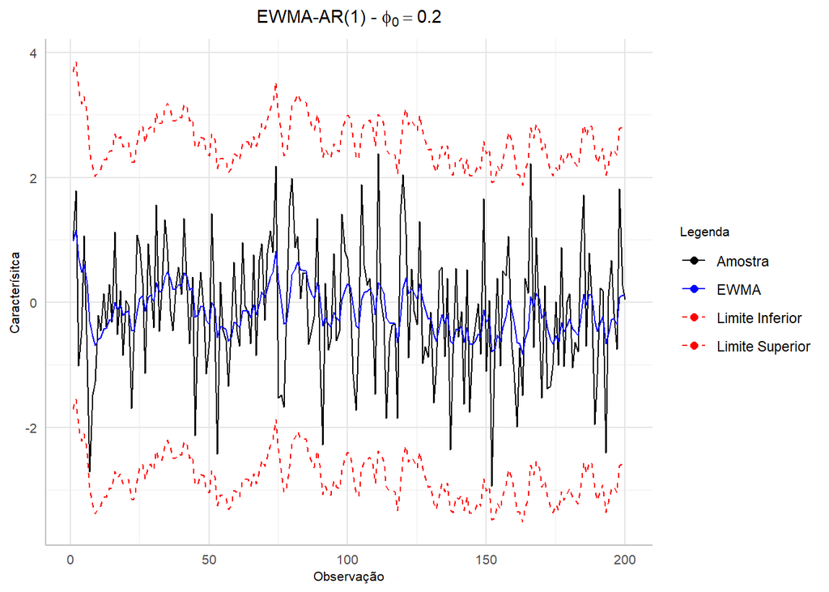

```r
ggplot(data = df_cc %>% filter(phi_0 == 0.2)) +
  geom_line(aes(x = amostra, y = limite_inferior, color = "Limite Inferior"), linetype = "dashed") +
  geom_line(aes(x = amostra, y = limite_superior, color = "Limite Superior"), linetype = "dashed") +
  geom_line(aes(x = amostra, y = observacao, color = "Amostra")) +
  geom_line(aes(x = amostra, y = ewma, color = "EWMA")) +
  geom_point(data = . %>% filter(observacao < limite_inferior | observacao > limite_superior),
             aes(x = amostra, y = observacao, color = "Fora de controle"), size = 2) +
  labs(x = "Observação", y = "Caracterísitca", color = "Legenda") +
  scale_color_manual(values = c(
    "Amostra" = "black",
    "EWMA" = "blue",
    "Limite Inferior" = "red",
    "Limite Superior" = "red",
    "Fora de controle" = "red"
  )) +
  ggtitle(TeX("EWMA-AR(1) - $\\phi_0 = 0.2$")) +
  theme.base
```

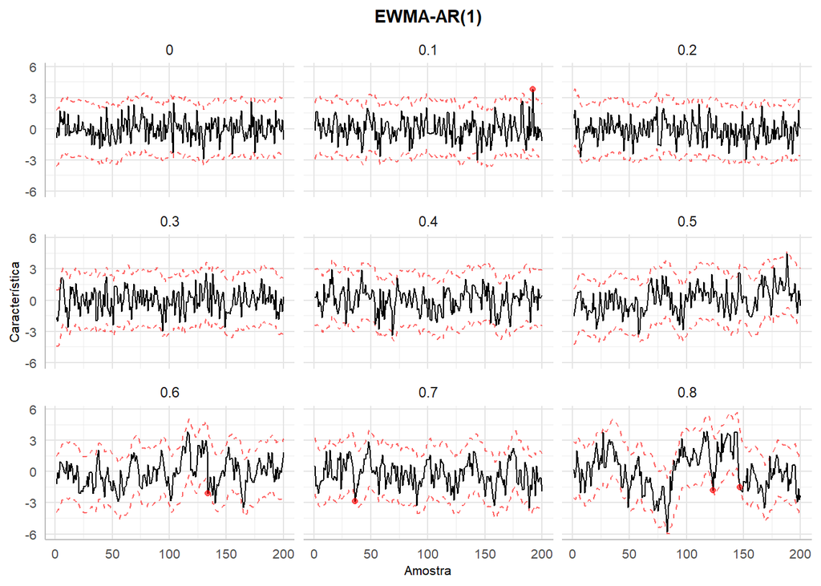

```r
ggplot(data = df_cc) +
  geom_line(aes(x = amostra, y = limite_inferior), linetype = "dashed", color = "red", alpha = 0.6) +
  geom_line(aes(x = amostra, y = limite_superior), linetype = "dashed", color = "red", alpha = 0.6) +
  geom_line(aes(x = amostra, y = observacao)) +
  # plot points outside control limits
  geom_point(data = . %>% filter(observacao < limite_inferior | observacao > limite_superior),
             aes(x = amostra, y = observacao), color = "red", alpha = 0.6) +
  labs(x = "Amostra", y = "Característica") +
  ggtitle("EWMA-AR(1)") +
  theme.base +
  facet_wrap(~phi_0)
```

Olhando agora para proporção de amostras fora de controle para cada $\phi_0$.

```r
df_fora_controle <- df_cc %>% group_by(phi_0) %>%
  summarise(
    "quantidade" = sum(observacao < limite_inferior | observacao > limite_superior),
    "fora_controle" = 100 * sum(observacao < limite_inferior | observacao > limite_superior) / n()
  )

kable(
  (function() {
    tabela <- df_fora_controle
    colnames(tabela) <- c("$\\phi_0$", "Amostras fora de controle", "Proporção (%)")
    tabela
  })(),
  caption = "Proporção de amostras fora de controle para CC EWMA-AR(1)",
  align = 'c',
  digits = 2
)
```

Proporção de amostras fora de controle para CC EWMA-AR(1)

| $\phi_0$ | Amostras fora de controle | Proporção (%) |
| --- | --- | --- |
| 0.0 | 0 | 0.0 |
| 0.1 | 1 | 0.5 |
| 0.2 | 0 | 0.0 |
| 0.3 | 0 | 0.0 |
| 0.4 | 0 | 0.0 |
| 0.5 | 0 | 0.0 |
| 0.6 | 1 | 0.5 |
| 0.7 | 1 | 0.5 |
| 0.8 | 2 | 1.0 |

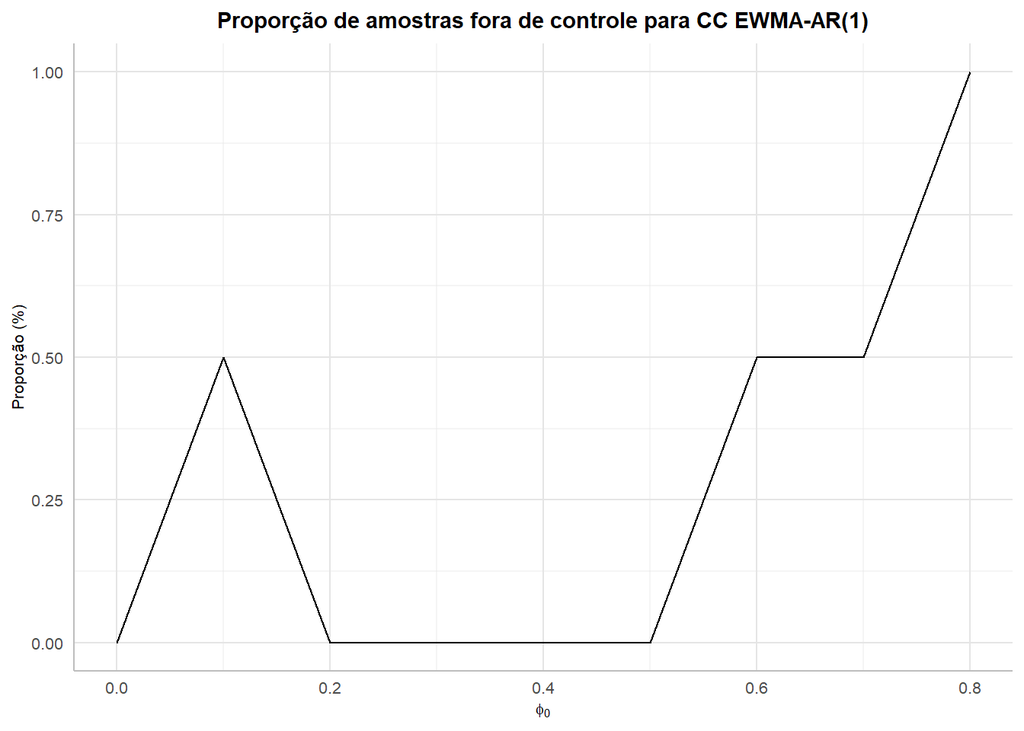

```r
ggplot(data = df_fora_controle, aes(x = phi_0, y = fora_controle)) +
  geom_line() +
  labs(x = TeX("$\\phi_0$"), y = "Proporção (%)") +
  ggtitle("Proporção de amostras fora de controle para CC EWMA-AR(1)") +
  theme.base
```

## Extra

Vamos verificar isso plotando vários gráficos de controle para diferentes valores de $\lambda$.

```r
computa_ewma_do_meu_lambda <- function(dados, lambda, pos_inicial = 1) {
  ewma <- ewma_ar(
    dados,
    lambda = ifelse(0, 0.001, lambda)
  )

  n <- length(dados)
  amost_ <- pos_inicial:(pos_inicial + n - 1)
  limites <- 3 * sigma2_sd * sqrt((lambda * (1 - (1 - lambda)^(2 * amost_))) / (2 - lambda))
  data.frame(
    lambda = lambda,
    observacao = as.numeric(dados),
    amostra = 1:n,
    ewma = ewma$ewma,
    residuos = ewma$residuos,
    li = ewma$ewma - limites,
    ls = ewma$ewma + limites
  )
}

# computa_ewma_do_meu_lambda(amostra_inicial$serie, 0.2)
```

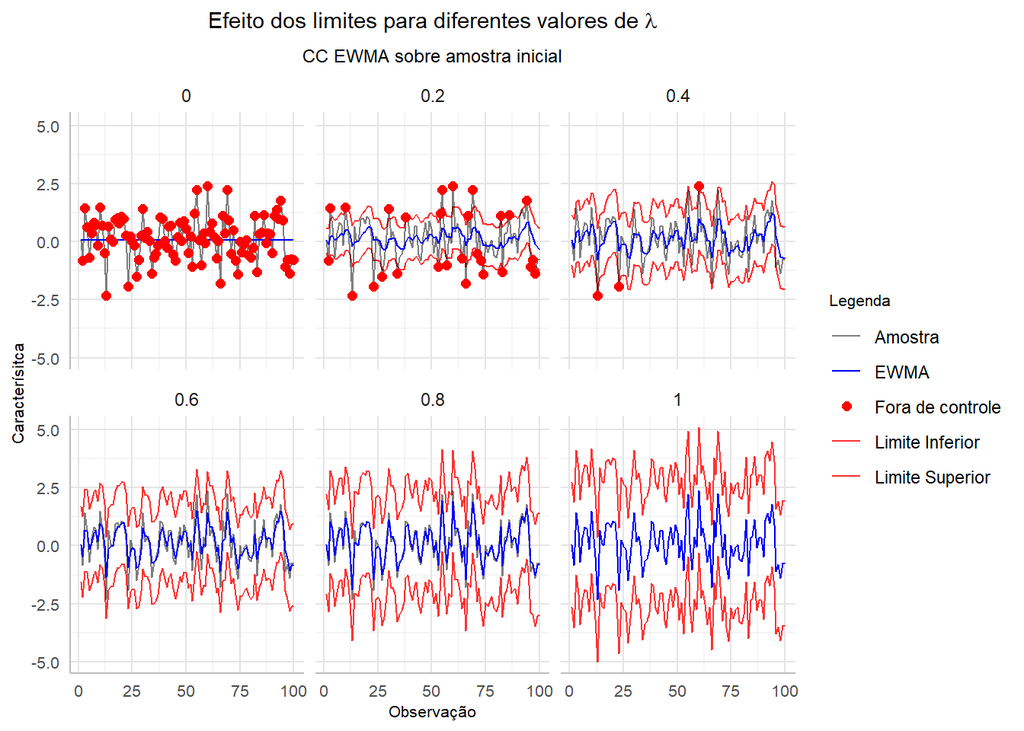

```r
meus_lambdas_df <- data.frame()

for (lambda in seq(0, 1, 0.2)) {
  df <- computa_ewma_do_meu_lambda(amostra_inicial$serie, lambda)
  meus_lambdas_df <- rbind(meus_lambdas_df, df)
}

ggplot(data = meus_lambdas_df) +
  geom_line(aes(x = amostra, y = li, color = "Limite Inferior")) +
  geom_line(aes(x = amostra, y = ls, color = "Limite Superior")) +
  geom_line(aes(x = amostra, y = observacao, color = "Amostra")) +
  geom_line(aes(x = amostra, y = ewma, color = "EWMA")) +
  geom_point(data = . %>% filter(observacao < li | observacao > ls),
             aes(x = amostra, y = observacao, color = "Fora de controle"), size = 2) +
  labs(x = "Observação", y = "Caracterísitca", color = "Legenda") +
  scale_color_manual(
    values = c(
      "Limite Inferior" = adjustcolor("red", alpha.f = 0.8),
      "Limite Superior" = adjustcolor("red", alpha.f = 0.8),
      "Amostra" = adjustcolor("black", alpha.f = 0.5),
      "EWMA" = "blue",
      "Fora de controle" = "red"
    )
  ) +
  labs(
    title = TeX("Efeito dos limites para diferentes valores de $\\lambda$"),
    subtitle = "CC EWMA sobre amostra inicial"
  ) +
  theme.base +
  facet_wrap(~lambda)
```

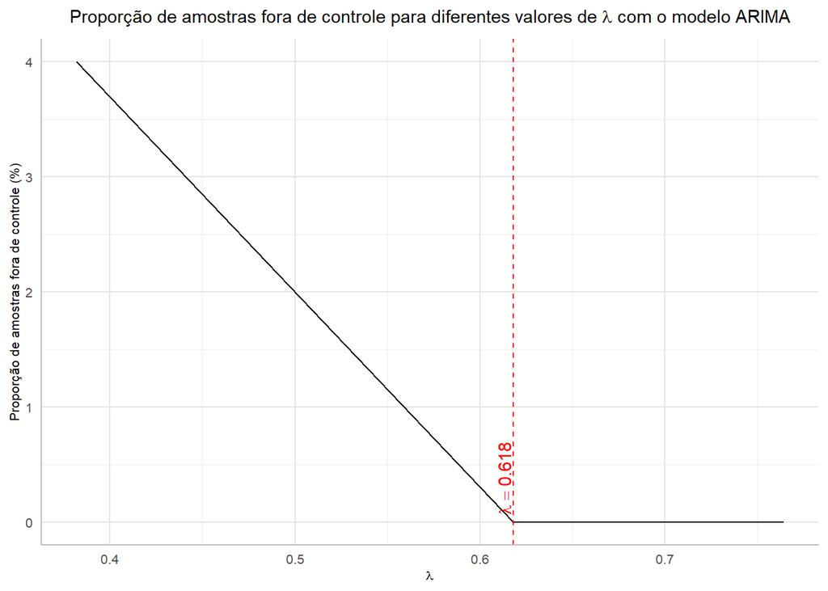

```r
meus_lambdas_verificados <- c()
minhas_proporcoes_fora_de_controle <- c()
verifica_meu_lambda <- function(lambda) {
  ewma <- computa_ewma_do_meu_lambda(amostra_inicial$serie, lambda)

  proporcao <- 100 * sum(
    length(amostra_inicial$serie[amostra_inicial$serie < ewma$li | amostra_inicial$serie > ewma$ls])
  ) / PARAMETROS$n_h0
  meus_lambdas_verificados <<- c(meus_lambdas_verificados, lambda)
  minhas_proporcoes_fora_de_controle <<- c(minhas_proporcoes_fora_de_controle, proporcao)
  proporcao
}


meu_lambda_otimo <- optimize(verifica_meu_lambda, c(0, 1))
meus_lambdas_df <- data.frame(lambda = meus_lambdas_verificados, erro = minhas_proporcoes_fora_de_controle)

ggplot(data = meus_lambdas_df) +
  geom_line(aes(x = lambda, y = erro)) +
  geom_vline(xintercept = meu_lambda_otimo$minimum, linetype = "dashed", color = "red") +
  annotate("text", x = meu_lambda_otimo$minimum, y = 0,
           label = TeX(sprintf("$\\lambda=%.3f$", meu_lambda_otimo$minimum)), color = "red",
           hjust = -0.1, vjust = -0.2, na.rm = T, angle = 90) +
  labs(x = TeX("$\\lambda$"), y = "Proporção de amostras fora de controle (%)") +
  ggtitle(TeX("Proporção de amostras fora de controle para diferentes valores de $\\lambda$ com o modelo ARIMA")) +
  theme.base
```

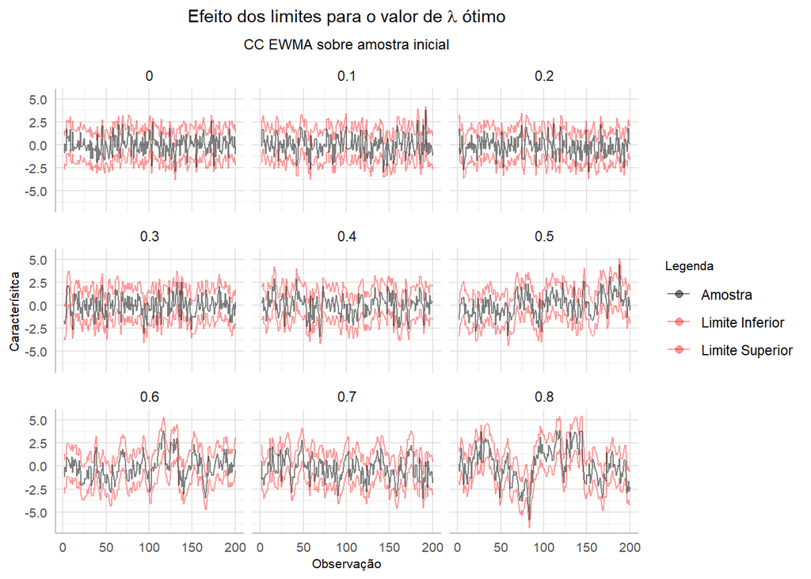

```r
df_cc_meu_lambda <- data.frame()
meu_lambda <- meu_lambda_otimo$minimum
erro_sobre_amostra_inicial <- ewma_ar(amostra_inicial$serie, lambda = meu_lambda)$residuos
sigma2_meu_lambda <- sum(erro_sobre_amostra_inicial^2) / PARAMETROS$n_h0

for (i in 1:n_simulacoes) {
  observacao <- as.numeric(amostras_subsequentes[[i]])
  phi_0 <- phi_0_para_amostras_seguintes[[i]]
  df <- computa_ewma_do_meu_lambda(observacao, meu_lambda, 101)
  df$phi_0 <- phi_0
  df_cc_meu_lambda <- rbind(df_cc_meu_lambda, df)
}

ggplot(data = df_cc_meu_lambda) +
  geom_line(aes(x = amostra, y = li, color = "Limite Inferior")) +
  geom_line(aes(x = amostra, y = ls, color = "Limite Superior")) +
  geom_line(aes(x = amostra, y = observacao, color = "Amostra")) +
  geom_point(data = . %>% filter(observacao < li | observacao > ls),
             aes(x = amostra, y = observacao, color = "Fora de controle"), size = 2) +
  labs(x = "Observação", y = "Caracterísitca", color = "Legenda") +
  scale_color_manual(
    values = c(
      "Limite Inferior" = adjustcolor("red", alpha.f = 0.4),
      "Limite Superior" = adjustcolor("red", alpha.f = 0.4),
      "Amostra" = adjustcolor("black", alpha.f = 0.5),
      "Fora de controle" = "red"
    )
  ) +
  labs(
    title = TeX("Efeito dos limites para o valor de $\\lambda$ ótimo"),
    subtitle = "CC EWMA sobre amostra inicial"
  ) +
  theme.base +
  facet_wrap(~phi_0)
```